# Exam : Fake News Detector - Case Study

**Simon Weiss**

29.03.2021

TBS MSc Artifical Intelligence and Business Analytics

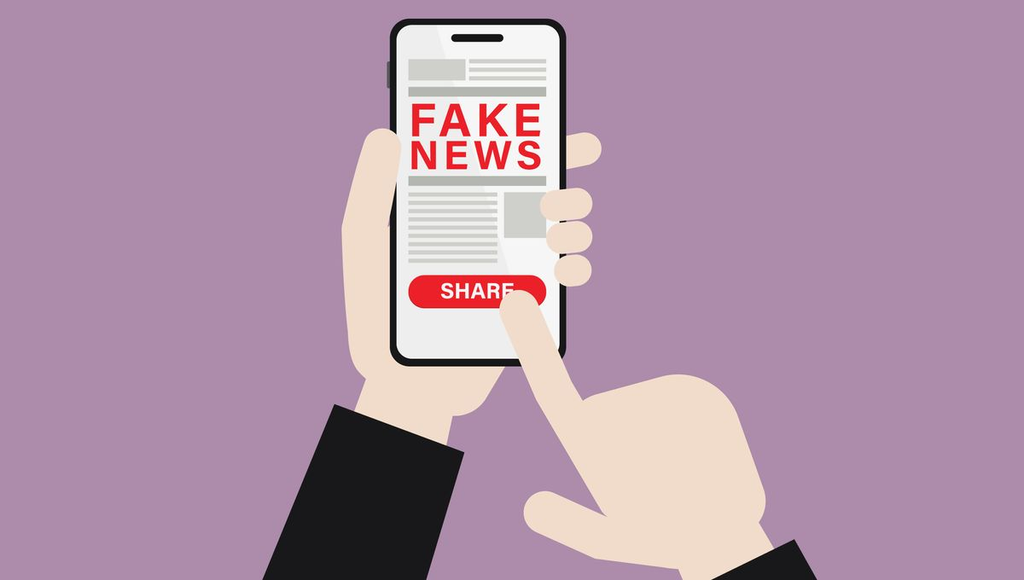

## 1. Introduction

### 1.1 Context

Fake news has been there since before the advent of the Internet.  
They are widely accepted to be fictitious articles deliberately fabricated to deceive readers. Social media and news outlets publish fake news to increase readership or as part of psychological warfare.

The latest hot topic in the news is fake news and many are wondering what data scientists can do to detect it and stymie its viral spread.

### 1.2 Objective

The objective of this notebook and its attached report is to use Machine learning in order to construct a fake news detection algorithm so as to predict if one news is True or Fake and thus study the possibilities of data science in the detection of fake news.  
Based on our results, we will be able to develop initial recommendations to any company or organisation that is trying to counteract fake news.

### 1.3 Datasets

Our dataset consists of two parts: a training set and a testing set.  
We will use our training set to build our models to predict on the test dataset which articles are considered fake or not.

- id: unique id for a news article
- title: the title of a news article
- author: author of the news article
- text: the text of the article; could be incomplete
- label: a label that marks the article as potentially unreliable o 1: unreliable o 0: reliable

### 1.4 Results

Best Models according to accuracy : 1) 0.971000 Support Vector Machines  
2) 0.969000 Stochastic Gradient Decent  
3) 0.9626670 Perceptron

## 2. Exploring the data

### 2.1 Loading libraries and dataset

```python
# data analysis and wrangling
import pandas as pd
import numpy as np
import random as rnd
import os

# visualization
import seaborn as sns
import matplotlib.pyplot as plt
%matplotlib inline
import warnings
warnings.filterwarnings('ignore')

# Words
import nltk
import re
from wordcloud import WordCloud

from nltk.stem.porter import *
from nltk.tokenize import word_tokenize
from nltk.corpus import stopwords
```

```python
#Loading the datasets

train_df = pd.read_csv('./data/training_set22.csv',index_col='Unnamed: 0')
test_df = pd.read_csv('./data/testing_set22.csv',index_col='Unnamed: 0')
```

### 2.2 Analyze by describing data

Which features are available in the dataset?

```python
print(train_df.columns.values)
```

```
['id' 'title' 'author' 'text' 'label']
```

```python
train_df.head()
```

|  | id | title | author | text | label |
| --- | --- | --- | --- | --- | --- |
| 5973 | 5972 | Report: Facebook Pays ’Army’ of Filipinos to P... | Lucas Nolan | Facebook reportedly pays an army of Filipino c... | 0 |
| 11304 | 11303 | WikiLeaks: Hillary Clinton knew Saudi, Qatar w... | wmw_admin | SEE ALSO: Why Hillary Clinton is Responsible f... | 1 |
| 3797 | 3796 | Apple iPhone, Once a Status Symbol in China, L... | Paul Mozur | HONG KONG — Since 2010, Yu Kai has followed... | 0 |
| 11197 | 11196 | U.F.C. Sells Itself for $4 Billion - The New Y... | Michael J. de la Merced | SAN FRANCISCO — Ultimate Fighting Champions... | 0 |
| 1490 | 1489 | At the Mosul Front: Traps, Smoke Screens and S... | Bryan Denton and Michael R. Gordon | Mr. Denton, a Times photographer, and Mr. Gord... | 0 |

```python
test_df.head()
```

|  | id | title | author | text |
| --- | --- | --- | --- | --- |
| 3971 | 24770 | WATCH: Diamond And Silk Slam Obama, Kerry For ... | Deborah Danan | TEL AVIV — The YouTube sensations known as ... |
| 2219 | 23018 | Elite Soccer Clubs Sign Gamers to Compete in E... | Jack Williams | Every now and again, Koen Weijland feels like ... |
| 677 | 21476 | #NotMyPresident? #DrainTheSwamp? The REAL Revo... | Corbett | Podcast: Play in new window \| Download \| Embed... |
| 3226 | 24025 | Election 2016 Current Votes in 8 Battleground ... | smith.j | For decades, media networks, newspapers, and j... |
| 789 | 21588 | Bus Driver Pulls Over to Stop Suicidal Woman f... | Breitbart TV | An Ohio bus driver’s quick thinking last month... |

Our dataset is well import. Let us check data information

```python
train_df.info()
print(' ')
print('=*='*20)
print(' ')
test_df.info()
```

```
<class 'pandas.core.frame.DataFrame'>
Int64Index: 15000 entries, 5973 to 2933
Data columns (total 5 columns):
 #   Column  Non-Null Count  Dtype
---  ------  --------------  -----
 0   id      15000 non-null  int64
 1   title   14600 non-null  object
 2   author  13599 non-null  object
 3   text    14974 non-null  object
 4   label   15000 non-null  int64
dtypes: int64(2), object(3)
memory usage: 703.1+ KB

=*==*==*==*==*==*==*==*==*==*==*==*==*==*==*==*==*==*==*==*=

<class 'pandas.core.frame.DataFrame'>
Int64Index: 4000 entries, 3971 to 5
Data columns (total 4 columns):
 #   Column  Non-Null Count  Dtype
---  ------  --------------  -----
 0   id      4000 non-null   int64
 1   title   3908 non-null   object
 2   author  3600 non-null   object
 3   text    3995 non-null   object
dtypes: int64(1), object(3)
memory usage: 156.2+ KB
```

```python
#Searching for null values.

train_df.isna().sum()
```

```
id           0
title      400
author    1401
text        26
label        0
dtype: int64
```

```python
test_df.isna().sum()
```

```
id          0
title      92
author    400
text        5
dtype: int64
```

We have null values. We will check if those empyt texts will be a problem in the futur for our model. For now, let's keep them as N.A

### 2.3 Target analysis : Check for Class Imbalance¶

```python
train_df['label'].value_counts()
```

```
1    7508
0    7492
Name: label, dtype: int64
```

1 stands for unreliable and 0 for reliable.

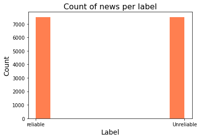

```python
plt.hist(train_df['label'], color = 'coral', align='mid')
plt.ylabel('Count', fontsize=14)
col_names=['reliable','Unreliable']
x_values = np.arange(0, len(col_names))


plt.xticks(x_values, col_names)
plt.xlabel('Label', fontsize=14)
plt.title('Count of news per label', fontsize = 16)
```

From this plot, we can observe that we do not have a class imbalance. There are very slightly more unfounded news, which is not a problem.

### 2.4 Check for text content

Let us check the content of of 3 text columns : author, the title and the content of the article.  
We will use our training dataset content for this check since our test dataset has the same structure.

```python
t = train_df["author"].to_list()
for i in range(5):
    print('Author of article '+str(i+1)+': '+t[i])
```

```
Author of article 1: Lucas Nolan
Author of article 2: wmw_admin
Author of article 3: Paul Mozur
Author of article 4: Michael J. de la Merced
Author of article 5: Bryan Denton and Michael R. Gordon
```

```python
t = train_df["title"].to_list()
for i in range(5):
    print('Title of article '+str(i+1)+': '+t[i])
```

```
Title of article 1: Report: Facebook Pays ’Army’ of Filipinos to Police ’Offensive’ Material - Breitbart
Title of article 2: WikiLeaks: Hillary Clinton knew Saudi, Qatar were funding ISIS – but still took their money for Foundation
Title of article 3: Apple iPhone, Once a Status Symbol in China, Loses Its Luster - The New York Times
Title of article 4: U.F.C. Sells Itself for $4 Billion - The New York Times
Title of article 5: At the Mosul Front: Traps, Smoke Screens and Suicide Bombers - The New York Times
```

Article are quite long, we print only our 2 first articles

```python
t = train_df["text"].to_list()
for i in range(2):
    print('Content of article '+str(i+1)+': '+t[i])
```

```
Content of article 1: Facebook reportedly pays an army of Filipino content curators to police content on the social network’s platform. [The Daily Mail reports that Facebook has been hiring young Filipinos to act as content curators on the Facebook platform. The workers reportedly work grueling shif…
Content of article 2: SEE ALSO: Why Hillary Clinton is Responsible for US Failures in Libya and Syria
According to FOX News , FBI sources have said that ‘indictments are likely’ for the Clinton Foundation investigation. One only wonders how this latest Assange revelation will factor into the wider investigation – as it goes right to the heart of the national security and foreign policy – two things …
Assange went on to explain the deep ramifications of this latest criminal allegation against Clinton and her family foundation:
“All serious analysts know, and even the US government has agreed, that some Saudi figures have been supporting ISIS and funding ISIS, but the dodge has always been that it is some “rogue” princes using their oil money to do whatever they like, but actually the government disapproves. But that email…
During their 25-minute interview filmed at the Ecuadorian Embassy in London, Assange and Pilger discussed the obvious conflict of interest between Clinton as Secretary of State, the Clinton Foundation and Gulf monarchies who financed them. The following is an excerpt from the interview transcript:
John Pilger: The Saudis, the Qataris, the Moroccans, the Bahrainis, particularly the first two, are giving all this money to the Clinton Foundation, while Hillary Clinton is secretary of state, and the State Department is approving massive arms sales, particularly Saudi Arabia.
Julian Assange: Under Hillary Clinton – and the Clinton emails reveal a significant discussion of it – the biggest-ever arms deal in the world was made with Saudi Arabia: more than $80 billion. During her tenure, the total arms exports from the US doubled in dollar value.
JP: Of course, the consequence of that is that this notorious jihadist group, called ISIL or ISIS, is created largely with money from people who are giving money to the Clinton Foundation?
JA: Yes.
Watch a brief preview of the interview here :
Courtesy Peter Myers
```

Article are quite long and have a lot of content. We will have to process them in order to pass them in a ML model

One author could have written different article. Let us count the number of author in both our training and test datastets

```python
train_df['author'].value_counts().head(n=20)
```

```
Pam Key                178
admin                  150
Jerome Hudson          114
John Hayward           108
Charlie Spiering       106
Warner Todd Huston      97
Katherine Rodriguez     92
Daniel Nussbaum         88
Jeff Poor               84
Ian Hanchett            77
Breitbart News          76
Trent Baker             74
Bob Price               74
Charlie Nash            71
AWR Hawkins             71
Breitbart London        70
Starkman                66
Ben Kew                 66
Pakalert                66
Alex Ansary             63
Name: author, dtype: int64
```

```python
test_df['author'].value_counts().head(n=20)
```

```
Pam Key                45
Jerome Hudson          42
admin                  40
Daniel Nussbaum        29
Charlie Spiering       27
Charlie Nash           26
Joel B. Pollak         25
Katherine Rodriguez    24
Warner Todd Huston     24
Ian Hanchett           24
Breitbart News         23
AWR Hawkins            23
Breitbart London       19
Tom Ciccotta           19
BareNakedIslam         19
John Hayward           18
EdJenner               18
Ben Kew                17
The Saker              17
Chris Tomlinson        17
Name: author, dtype: int64
```

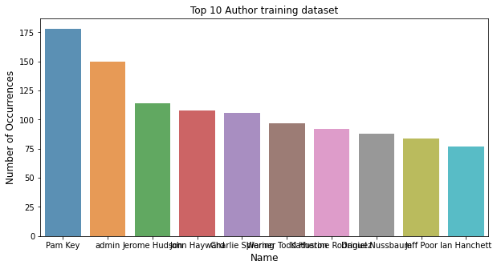

```python
# Plotting a bar graph of the number of author
author_count  = train_df['author'].value_counts()
author_count = author_count[:10,]
plt.figure(figsize=(10,5))
sns.barplot(author_count.index, author_count.values, alpha=0.8)
plt.title('Top 10 Author training dataset')
plt.ylabel('Number of Occurrences', fontsize=12)
plt.xlabel('Name', fontsize=12)
plt.show()
```

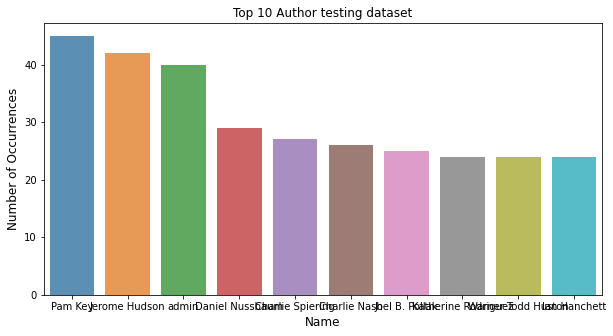

```python
# Plotting a bar graph of the number of author
author_count  = test_df['author'].value_counts()
author_count = author_count[:10,]
plt.figure(figsize=(10,5))
sns.barplot(author_count.index, author_count.values, alpha=0.8)
plt.title('Top 10 Author testing dataset')
plt.ylabel('Number of Occurrences', fontsize=12)
plt.xlabel('Name', fontsize=12)
plt.show()
```

We can observe that some authors are much more present than others. Maybe some authors are particularly prone to write fake news. We also observe that we find some of the top authors in our test and training dataset.

Let us check the same thing for the title

```python
train_df['title'].value_counts().head(n=20)
```

```
Will Barack Obama Delay Or Suspend The Election If Hillary Is Forced Out By The New FBI Email Investigation?                4
Michael Moore Owes Me $4.99                                                                                                 4
The Dark Agenda Behind Globalism And Open Borders                                                                           4
Get Ready For Civil Unrest: Survey Finds That Most Americans Are Concerned About Election Violence                          4
Let’s Be Clear – A Vote For Warmonger Hillary Clinton Is A Vote For World War 3                                             4
Las imágenes libres de derechos más destacadas de la semana                                                                 4
Brother of Clinton’s Campaign Chair is an Active Foreign Agent on the Saudi Arabian Payroll                                 3
Televisión: lo más visto ayer                                                                                               3
Break the Silence or Support Self-Determination? In Syria, the Answer Should be Obvious                                     3
The Pathologization of Dissent                                                                                              3
Not Just Hillary, Entire Obama Administration Exposed for Using Private Email to Avoid FOIA Requests                        3
President Elect Trump – A New Era of Unpredictability Awaits                                                                3
FDA Found Manipulating The Media In Favor Of Big Pharma                                                                     3
Trump warns of World War III if Clinton is elected                                                                          3
The U.S./Turkey Plan For “Seizing, Holding, And Occupying” Syrian Territory In Raqqa                                        3
Dennis Kucinich’s Extraordinary Warning on D.C.’s Think Tank Warmongers                                                     3
WWN’s Horoscopes                                                                                                            3
What to Cook This Week - The New York Times                                                                                 3
Woman Arrested On Own Property After Her Land Was Stolen By DAPL                                                            3
Biden Blames “Lazy American Women” For The Economy: “They Sit Around Doing Nothing, Only Hillary Can Force Them To Work”    3
Name: title, dtype: int64
```

```python
test_df['title'].value_counts().head(n=20)
```

```
The De Facto US/Al Qaeda Alliance                                                                                                                       2
TRUMP CALLS FOR TEACHING ‘PATRIOTISM’ IN SCHOOLS                                                                                                        2
When Slaveholders Controlled the Government—An Interview with Matthew Karp                                                                              2
One of the Most Undervalued Storable Survival Foods                                                                                                     2
Thousands Of Buffalo Appear At Site Of Standing Rock Protest [Watch]                                                                                    2
The Modern History of ‘Rigged’ US Elections                                                                                                             2
Get Ready For Civil Unrest: Survey Finds That Most Americans Are Concerned About Election Violence                                                      2
Massive Voter Fraud In Texas                                                                                                                            2
CETA: Canada Has Challenged The EU’s Chemical Regulations 21 Times                                                                                      2
BREAKING: Racketeering indictment of Hillary Clinton now ‘likely’ as FOIA for Datto backup device reveals FBI possesses ALL the incriminating emails    2
2016 Shows Record Number of Refugee Deaths in Mediterranean                                                                                             1
Everyone now officially an artisan                                                                                                                      1
Colombian Opposition to Peace Deal Feeds Off Gay Rights Backlash - The New York Times                                                                   1
’Saturday Night Live’ Writer Tweets Barron Trump Will Be America’s ‘First Homeschool Shooter’                                                           1
Snow reports from around the Northland (Duluth) through 9 a.m. Saturday                                                                                 1
In Cranes’ Shadow, Los Angeles Strains to See a Future With Less Sprawl - The New York Times                                                            1
Netanyahu: U.S.-Israel Alliance is ’About to Get Stronger’                                                                                              1
Nature: The Ultimate Cure                                                                                                                               1
Christo’s Newest Project: Walking on Water - The New York Times                                                                                         1
Mexico Ends Its Soccer Frustration on U.S. Soil - The New York Times                                                                                    1
Name: title, dtype: int64
```

some titles appear several times. Maybe some articles appear twice.

### 2.5 Merge text context

We will merge all our text content that we have just analysed in one column both in training and testing dataset

```python
#We will join title, text and author to create the article feature
train_df['article'] = train_df['title']+""+train_df['text']+""+train_df['author']
```

```python
#We will join title, text and author to create the article feature
test_df['article'] = test_df['title']+""+test_df['text']+""+test_df['author']
```

```python
#Creating the final Dataframe with article and label.
train_df_final = train_df[['article','label']]
```

```python
# Create empty label target column in our test dataset
test_df['label']=""
```

```python
#Creating the final Dataframe test with article and label.
test_df_final = test_df[['article','label']]
```

Convert text article into str

```python
train_df_final['article'] = train_df_final['article'].astype(str)
test_df_final['article'] = test_df_final['article'].astype(str)
```

### 3.Preprocessing of the article

We will clean the article by removing the punctuation, the special characters, tokenize them, remove the stopwords in order to use machine learning models

```python
#Converting to lower case

train_df_final['article'] = train_df_final['article'].apply(lambda x: x.lower())
test_df_final['article'] = test_df_final['article'].apply(lambda x: x.lower())
```

```python
train_df_final['article'].head()
```

```
5973     report: facebook pays ’army’ of filipinos to p...
11304    wikileaks: hillary clinton knew saudi, qatar w...
3797     apple iphone, once a status symbol in china, l...
11197    u.f.c. sells itself for $4 billion - the new y...
1490     at the mosul front: traps, smoke screens and s...
Name: article, dtype: object
```

```python
#Removing punctuation

import string

def punctuation_removal(messy_str):
    clean_list = [char for char in messy_str if char not in string.punctuation]
    clean_str = ''.join(clean_list)
    return clean_str
```

```python
train_df_final['article'] = train_df_final['article'].apply(punctuation_removal)
test_df_final['article'] = test_df_final['article'].apply(punctuation_removal)
```

```python
train_df_final['article'].head()
```

```
5973     report facebook pays ’army’ of filipinos to po...
11304    wikileaks hillary clinton knew saudi qatar wer...
3797     apple iphone once a status symbol in china los...
11197    ufc sells itself for 4 billion  the new york t...
1490     at the mosul front traps smoke screens and sui...
Name: article, dtype: object
```

```python
test_df_final['article'].head()
```

```
3971    watch diamond and silk slam obama kerry for ’s...
2219    elite soccer clubs sign gamers to compete in e...
677     notmypresident draintheswamp the real revoluti...
3226    election 2016 current votes in 8 battleground ...
789     bus driver pulls over to stop suicidal woman f...
Name: article, dtype: object
```

```python
#Converting X to format removing and punctuation stopwords in the process
X = []
stop_words = set(nltk.corpus.stopwords.words("english"))
tokenizer = nltk.tokenize.RegexpTokenizer(r'\w+')
for par in train_df_final["article"].values:
    tmp = []
    sentences = nltk.sent_tokenize(par)
    for sent in sentences:
        sent = sent.lower()
        tokens = tokenizer.tokenize(sent)
        filtered_words = [w.strip() for w in tokens if w not in stop_words and len(w) > 1]
        tmp.extend(filtered_words)
    X.append(tmp)
```

```python
train_df_final["article"]=X
```

```python
train_df_final["article"]=train_df_final["article"].astype(str)
```

```python
train_df_final.head()
```

|  | article | label |
| --- | --- | --- |
| 5973 | ['report', 'facebook', 'pays', 'army', 'filipi... | 0 |
| 11304 | ['wikileaks', 'hillary', 'clinton', 'knew', 's... | 1 |
| 3797 | ['apple', 'iphone', 'status', 'symbol', 'china... | 0 |
| 11197 | ['ufc', 'sells', 'billion', 'new', 'york', 'ti... | 0 |
| 1490 | ['mosul', 'front', 'traps', 'smoke', 'screens'... | 0 |

We apply the same step for our testing dataset

```python
#Converting X to format removing and punctuation stopwords in the process
X = []
stop_words = set(nltk.corpus.stopwords.words("english"))
tokenizer = nltk.tokenize.RegexpTokenizer(r'\w+')
for par in test_df_final["article"].values:
    tmp = []
    sentences = nltk.sent_tokenize(par)
    for sent in sentences:
        sent = sent.lower()
        tokens = tokenizer.tokenize(sent)
        filtered_words = [w.strip() for w in tokens if w not in stop_words and len(w) > 1]
        tmp.extend(filtered_words)
    X.append(tmp)
```

```python
test_df_final["article"]=X
```

```python
test_df_final["article"]=test_df_final["article"].astype(str)
```

```python
test_df_final.head()
```

|  | article | label |
| --- | --- | --- |
| 3971 | ['watch', 'diamond', 'silk', 'slam', 'obama', ... |  |
| 2219 | ['elite', 'soccer', 'clubs', 'sign', 'gamers',... |  |
| 677 | ['notmypresident', 'draintheswamp', 'real', 'r... |  |
| 3226 | ['election', '2016', 'current', 'votes', 'batt... |  |
| 789 | ['bus', 'driver', 'pulls', 'stop', 'suicidal',... |  |

### 4. Article Post-processing EDA

Now that we have cleaned our data and convert them into the right format, we can do some nice vizualisation.

First, let us plot wordcloud in order to grasp the most frequent terms in our article

```python
%matplotlib inline

from wordcloud import WordCloud

all_words = ' '.join([text for text in train_df_final.article])

wordcloud = WordCloud(width= 800, height= 500,
                          max_font_size = 110,
                          collocations = False).generate(all_words)
```

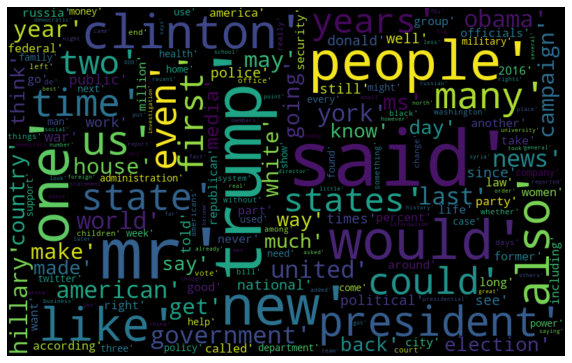

```python
import matplotlib.pyplot as plt

plt.figure(figsize=(10,7))
plt.imshow(wordcloud, interpolation='bilinear')
plt.axis("off")
plt.show()
```

Visualizing the true news with Wordcloud.

```python
train_df_final[train_df_final['label']==0]
```

|  | article | label |
| --- | --- | --- |
| 5973 | ['report', 'facebook', 'pays', 'army', 'filipi... | 0 |
| 3797 | ['apple', 'iphone', 'status', 'symbol', 'china... | 0 |
| 11197 | ['ufc', 'sells', 'billion', 'new', 'york', 'ti... | 0 |
| 1490 | ['mosul', 'front', 'traps', 'smoke', 'screens'... | 0 |
| 6758 | ['frank', 'gaffney', 'tillerson', 'incoherent'... | 0 |
| ... | ... | ... |
| 18667 | ['right', 'left', 'partisan', 'writing', 'miss... | 0 |
| 9954 | ['hirakhand', 'express', 'train', 'derails', '... | 0 |
| 19494 | ['lirr', 'train', 'crashed', 'going', 'twice',... | 0 |
| 19662 | ['putin', 'allegations', 'russian', 'meddling'... | 0 |
| 2933 | ['donald', 'trump', 'delta', 'air', 'lines', '... | 0 |

7492 rows × 2 columns

```python
%matplotlib inline

from wordcloud import WordCloud

all_words = ' '.join([text for text in train_df_final[train_df_final['label']==0].article])

wordcloud = WordCloud(width= 800, height= 500,
                          max_font_size = 110,
                          collocations = False).generate(all_words)
```

[figure not shown]

```python
import matplotlib.pyplot as plt

plt.figure(figsize=(10,7))
plt.imshow(wordcloud, interpolation='bilinear')
plt.axis("off")
plt.show()
```

```python
%matplotlib inline

from wordcloud import WordCloud

all_words = ' '.join([text for text in train_df_final[train_df_final['label']==1].article ])

wordcloud = WordCloud(width= 800, height= 500,
                          max_font_size = 110,
                          collocations = False).generate(all_words)
```

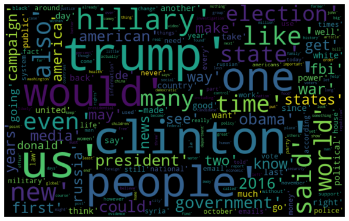

```python
import matplotlib.pyplot as plt

plt.figure(figsize=(10,7))
plt.imshow(wordcloud, interpolation='bilinear')
plt.axis("off")
plt.show()
```

Let us compare with our testing dataset

```python
%matplotlib inline

from wordcloud import WordCloud

all_words = ' '.join([text for text in test_df_final.article ])

wordcloud = WordCloud(width= 800, height= 500,
                          max_font_size = 110,
                          collocations = False).generate(all_words)
```

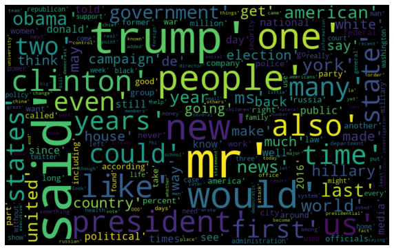

```python
import matplotlib.pyplot as plt

plt.figure(figsize=(10,7))
plt.imshow(wordcloud, interpolation='bilinear')
plt.axis("off")
plt.show()
```

Now we will plot the pareto chart to better visualize the frequencies of the words.

```python
## remove whitespace
from nltk import tokenize

token_space = tokenize.WhitespaceTokenizer()
```

```python
import seaborn as sns
import nltk

def pareto(text, column_text, quantity):
    all_words = ' '.join([text for text in text[column_text]])
    token_phrase = token_space.tokenize(all_words)
    frequency = nltk.FreqDist(token_phrase)
    df_frequency = pd.DataFrame({"Word": list(frequency.keys()),
                                   "Frequency": list(frequency.values())})
    df_frequency = df_frequency.nlargest(columns = "Frequency", n = quantity)
    plt.figure(figsize=(12,8))
    ax = sns.barplot(data = df_frequency, x = "Word", y = "Frequency", color = 'blue')
    ax.set(ylabel = "Count")
    plt.show()
```

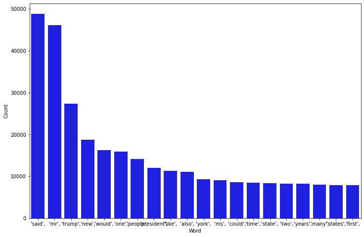

```python
#The 20 more frequent word in reliable article

pareto(train_df_final[train_df_final['label']==0], "article", 20)
```

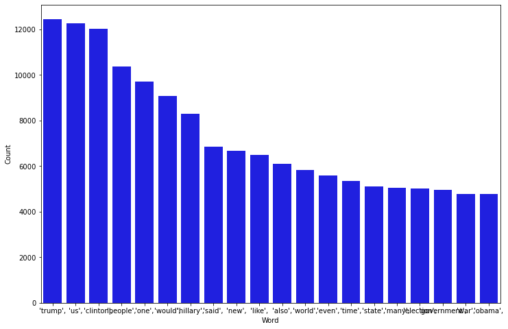

```python
#The 20 more frequent word in ureliable article

pareto(train_df_final[train_df_final['label']==1], "article", 20)
```

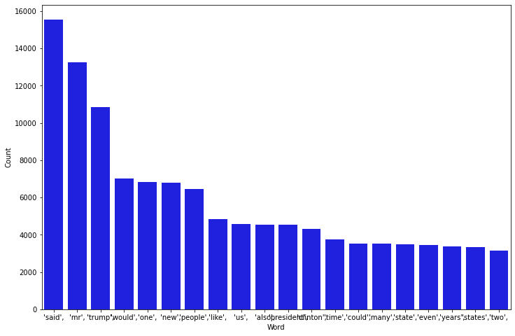

```python
#The 20 more frequent word in ureliable article

pareto(test_df_final, "article", 20)
```